# Instrumentation

Marc Nicollerat

# 8 Kraft- und Drehmomentsensoren

- Dehnungsmessstreifen
  - Messprinzip, Gleichungen
  - bi. triaxiale Varianten
- Kraftaufnehmer, Lastzelle
  - Messung der Verformung einer Lastzelle
  - Messung mit Dehnungsmessstreifen oder piezoelektrischem Sensor
- Drucksensor
  - Prinzip
  - Messung der Durchflussmenge
  - Mikrofon
- Drehmomentsensor

## 8.1 Dehnungsmessstreifen

Prinzip: Der Dehnungsmessstreifen ermöglicht die Messung der Dehnung eines elastischen Systems. Eine sehr geringe Verformung kann mit diesem Prinzip gemessen werden.

Beispiel für einen Spannungsmesser

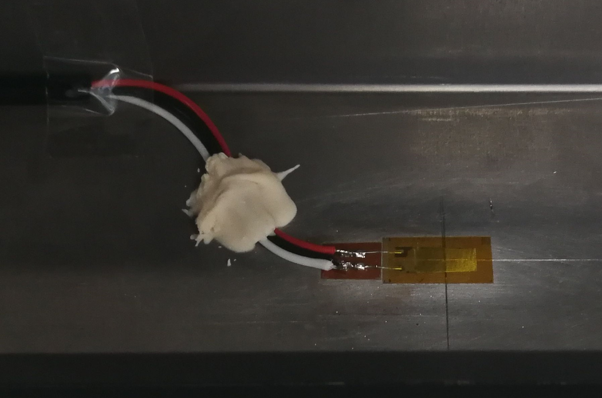

Installation eines Messgeräts an einem Profil

## 8.2 Gleichungen für die Spannungsmessung

- Beziehungen, die mit der Kraftmessung zusammenhängen. Man setzt zwischen der Beziehung des Messgeräts und den Gleichungen für die Dehnung des Mediums zusammen.

| DMS-Beziehung | $\frac{\Delta R}{R} = K \cdot \frac{\Delta L}{L}$ |
| --- | --- |
| Materialrelation | $\epsilon = \frac{\Delta L}{L} = \frac{F}{E*S} = \frac{ \sigma}{E}$ |

Parameter der Gleichungen

| $R, \Delta R$ | $[\Omega]$ | Nennwiderstand, Widerstandsänderung |
| --- | --- | --- |
| $K$ | $[1]$ | Eine charakteristische Konstante des Messgeräts |
| $\epsilon$ | $[1]$ | Relative Dehnung |
| $L, \Delta L$ | $[m]$ | Länge der Lehre, Längenänderung aufgrund von Beanspruchung |
| $F$ | $[N]$ | Aufgebrachte Kraft |
| $E$ | $[N/m^2]$ | Elastizitätsmodul |
| $S$ | $[m^2]$ | Materialoberfläche |
| $\sigma$ | $[P], [N/m^2]$ | Spannung |

## 8.3 Messbrücke

Es wird eine Weatstone-Brückenschaltung verwendet, um die Messgenauigkeit zu verbessern.

Bei einer bestimmten Spannung nimmt der Widerstand einiger Messgeräte ab, während der Widerstand anderer Messgeräte zunimmt.

Der Einfluss der Temperatur $\Delta R_T$ auf das Messgerät kann durch die Verwendung mehrerer Messgeräte, die in einer Brücke montiert sind, minimiert werden.

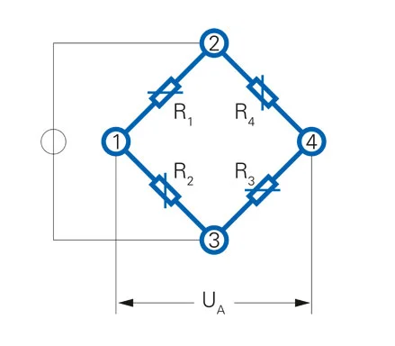

Wheatstone-Brücke

Die Ausgangsspannung hat diese Form :

Vollständige Brücke

$\displaystyle U_{A} = \frac{U_{0} \Delta R_{F}}{R_{0} + \Delta R_{T}}$

Halbbrücke

$\displaystyle U_{A} = \frac{U_{0} \Delta R_{F}}{2 \left(R_{0} + \Delta R_{T}\right)}$

Einfaches Messgerät

$\displaystyle U_{A} = \frac{U_{0} \left(\Delta R_{F} + \Delta R_{T}\right)}{2 \left(2 R_{0} + \Delta R_{F} + \Delta R_{T}\right)}$

**Tip**

Das jupyter notebook dev_8.1_pont_wheatstone.pynb zeigt die Details der Berechnung.

## 8.4 Arten von Dehnungsmessstreifen

Verschiedene Ausführungen von Dehnungsmessstreifen sind für bestimmte Messvarianten erhältlich.

Einfacher DMS

Full Bridge Gauge

[figure not shown]

Scherkraftmessgerät

Rosettenlehre

## 8.5 Kraftsensoren: Wägezelle

- Verformung eines bekannten Materials

$$\begin{array}a
\sigma = E \cdot \epsilon && \nu = \frac{\epsilon_y}{\epsilon_x}
\end{array}$$

wobei man $\sigma$ eine Spannung, $E$ den Elastizitätsmodul, $\epsilon$ die relative Dehnung, $\nu$ die Poissonzahl, $\epsilon_x$,$\epsilon_y$ die Längs- und die senkrechte Dehnung hat.

- Messung der Dehnung mit einem Dehnungsmessstreifen

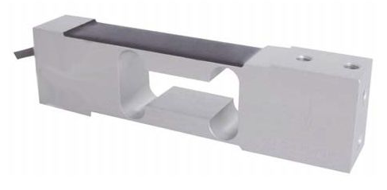

Wägezelle

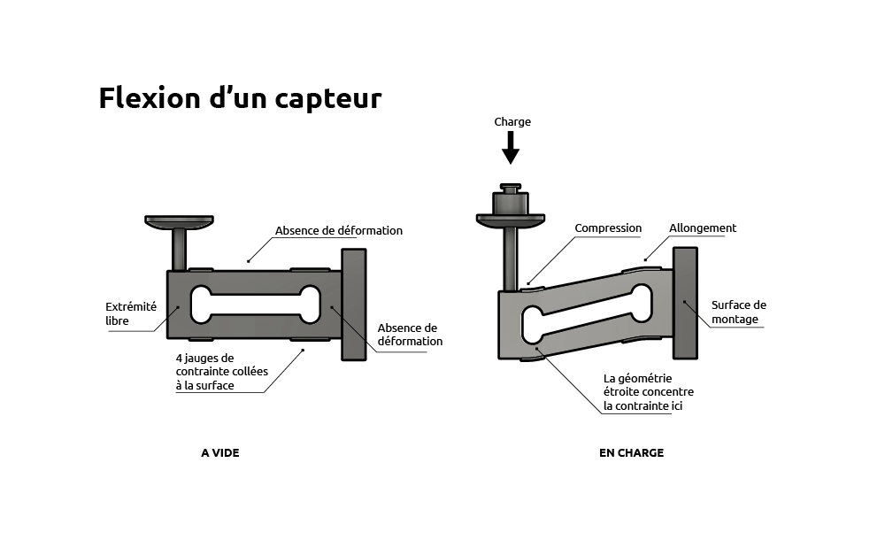

Funktionsprinzip

## 8.6 Piezoelektrischer Kraftsensor

- Die zu messende Kraft verformt einen Kristall.
- Das Prinzip ist ähnlich wie beim Beschleunigungsmesser

Beziehung zwischen Ladung und Spannung : $Q=C\cdot U$

Beziehung zwischen Kraft und Ladung : $Q=\beta \cdot F$

**Umgekehrt: Der Piezo-Sensor kann als Aktor dienen.**

- HF-Lautsprecher
- Ventil (Tintenstrahldrucker)

## 8.7 Drucksensor

Es gibt verschiedene Varianten des Drucksensors. Das Prinzip ist, dass die Kraft, die auf eine *Membran* mit bekannter Oberfläche ausgeübt wird, durch den Druck gemessen wird.

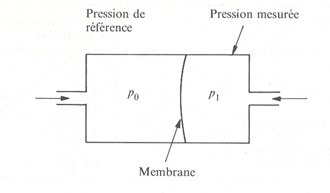

Prinzip des Drucksensors

$$Force = Pression \cdot Surface$$

- Relativer Drucksensor: Die Drücke auf beiden Seiten der *Membran* sind entgegengesetzt.
- Absoluter Drucksensor: Der Druck auf einer Seite ist bekannt und konstant, oder man hat ein Vakuum erzeugt.
- Mikrofon: Messung des dynamischen Drucks im hörbaren Frequenzbereich.

## 8.8 Durchflussmessung mit Druck

Ein sich bewegendes Fluid kann durch die Bernoulli-Gleichung modelliert werden

$$v^2/2 + g z + p/\rho = constante$$

[figure not shown]

Venturi Tube

Mit $p$ dem Druck am Studienpunkt, $ρ$ der Dichte des Fluids, $v$ der Geschwindigkeit am Studienpunkt, $g$ der Erdbeschleunigung, $z$ der Höhe des Studienpunkts.

| $v^2/2$ | kynetische Energie |
| --- | --- |
| $g z$ | potentielle Gravitationsenergie |
| $p/\rho$ | potentielle Volumenenergie |

Das Mikrofon ist ein Differenzdrucksensor … oder auch nicht

Das dynamische Kapselmikrofon besteht aus einer Spule, die fest mit der Membran verbunden ist und in das Feld eines Magneten gebracht wird.

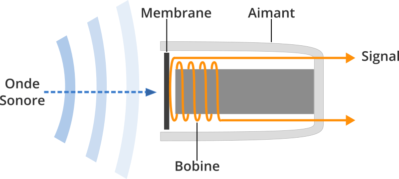

Prinzip des dynamischen Mikrofons

Das Elektretmikrofon oder Kondensatormikrofon besteht aus einer Membran, die eine der Platten eines Kondensators ist. Es muss mit Strom versorgt werden (*Phantomspeisung* wird als Gleichspannung über das Kabel geliefert).

[figure not shown]

Prinzip Elektretmikrofon

## 8.9 Charakteristik von Mikrofonen

Ein Mikrofon ist durch eine Richtcharakteristik gekennzeichnet. Die Richtcharakteristik hängt von der Konstruktion und der Membran ab.

Richtcharakteristikdiagramme verschiedener Kapseln

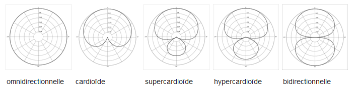

Richtcharakteristikdiagramme verschiedener Kapseln

## 8.10 Drehmomentmessung

- Die Drehmomentmessung folgt dem Prinzip der Kraftmessung. Gemessen wird die Verformung eines Baumes. Der Winkel $\alpha$ der Verformung folgt einer ähnlichen Beziehung wie bei der Feder :
  $$\Delta \alpha = K \cdot T$$

wobei $K$ eine Konstante der elastischen Verformung und $T$ das Drehmoment in [N/m] ist.

- Eine Messung der Verformung an einem statischen System ist mit einem Dehnungsmessstreifen möglich.

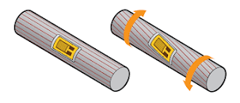

Prinzip mit Dehnungsmessstreifen

- Auf einer rotierenden Welle gibt es berührungslose Lösungen.

## 8.11 Sensor für Elektrofahrräder

Ein Drehmomentsensor für ein Elektrofahrrad kann wie auf Figure 1 dargestellt erfolgen.

[figure not shown]

Figure 1: Drehmomentsensor für Fahrrad

1. Eingangswelle
2. Ausgabebaum
3. Torsionswelle
4. Ausgerichtete Magnete zwischen Eingangs- und Ausgangswelle.
5. Magnetischer Kreis
6. Magnetsensor (magnetostriktiv).

Das Magnetfeld, das der Sensor misst, wird durch die Drehung der Abtriebswelle relativ zur Antriebswelle verändert. Die Drehung ist proportional zum Drehmoment, das auf die Torsionswelle ausgeübt wird.

## 8.12 Magnetostriktiver Sensor

- Das Magnetfeld oder die magnetischen Eigenschaften werden durch eine mechanische Belastung beeinflusst.

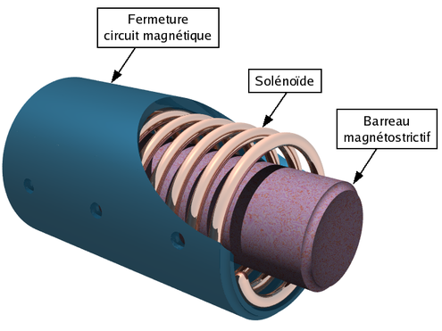

Prinzip des magnetostriktiven Sensors

- Durch einen konstanten Strom wird der Stab polarisiert
- Ein Wechselstrom ermöglicht die Messung von Änderungen der magnetischen Eigenschaften.
- Eine Belastung des Stabes kann so berührungslos gemessen werden.

[Produkt](https://sensel-measurement.fr/fr/24-couplemetre-rotatif)

## 8.13 Prüfkörper

Das Prinzip des Testkörpers ist eine Membran, die sich unter Druck verformt.

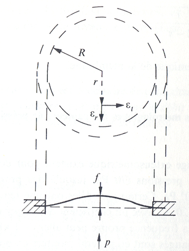

| Radiale Verformung | $\epsilon_r=\frac{3}{8}\cdot(1-\nu^2)\frac{R^2-3r^2}{E\cdot e^2}\cdot p$ |
| --- | --- |
| Tangentiale Verformung | $\epsilon_t=\frac{3}{8}\frac{R^2-r^2}{E\cdot e^2}\cdot p$ |
| Pfeil | $f=\frac{3}{16}\cdot(1-\nu^2)\frac{R^4}{E\cdot e^3}\cdot p$ |

**Tip**

Egal welches Maß, die Verformung ist immer proportional zum Druck!

- Messung der Verformung
  - Dehnungsmessstreifen, der misst $\epsilon_r$ oder $\epsilon_t$
  - Messung des *Durchhangs*. $f$

## 8.14 Übungen

- Übung 8.1: Verformung eines Stahlteils
- Übung 8.2: Verformung eines piezoelektrischen Quarzes